# TP - Introduction douce au text mining (avis Carrefour / Trustpilot) - Corrigé

R + Quarto - version avec code de référence

Author

Affiliation

Olivier Caron

Paris Dauphine - PSL

> **But du TP (🏁)**  
> Se familiariser pas à pas avec l’analyse de texte en R sur des avis clients (Trustpilot – Carrefour), **sans aller trop loin** : lecture des données, comptages simples, tokenisation, stopwords, bigrams, mini-stats lexicales, et un *aperçu* d’annotation UD avec `udpipe`.

> **Données (📁)** : `data/reviews_trustpilot_clean_pseudo.csv` (FR, pseudo-anonymisé).  
> **Colonnes (à titre indicatif)** : `review_id`, `author_name_pseudo`, `title`, `review`, `rating`, `date_published`, `page_url`.

## Avant de commencer

### Outils possibles (vous choisissez…)

- `quanteda` : corpus, DFM/DTM, fréquences, **collocations**, **cooccurrences**, **keyness**, lisibilité (via `quanteda.textstats`).
- `tidytext` : travail en format *tidy* (une ligne = un token), n-grammes simples.
- `stopwords` : listes de **mots vides** (FR).
- `stringr` / `dplyr` / `ggplot2` : manipulations + graphiques.
- `udpipe` : **POS tagging** + **dépendances** (Universal Dependencies) en fin de TP (petit aperçu).

> 💡 **Conseil** : restez simple, commentez vos choix, entraînez-vous à construire un rapport d’analyse.

## Préambule - Packages & lecture des données

```r
# install.packages(c("tidyverse","tidytext","stopwords","quanteda","quanteda.textstats","quanteda.textplots","udpipe","ggwordcloud"))

library(tidyverse)
library(tidytext)
library(stopwords)
library(quanteda)
library(quanteda.textstats)
library(quanteda.textplots)
library(udpipe)
library(ggwordcloud)
```

> Charger les avis depuis le chemin demandé.

```r
reviews <- readr::read_csv("data/reviews_trustpilot_clean_pseudo.csv",
                           show_col_types = FALSE, progress = FALSE)
dim(reviews)
```

```
[1] 3545    7
```

```r
dplyr::glimpse(reviews)
```

```
Rows: 3,545
Columns: 7
$ review_id          <chr> "68c2dc48ef348c350e4ecf54", "68c2048cc96894ccded00f…
$ author_name_pseudo <chr> "Patrick Fauré L'Auger", "René L'Lambért", "Colette…
$ title              <chr> "Valérie de l acceuil de carrefour Labege toulouse"…
$ review             <chr> "Valérie de l acceuil de carrefour Labege Toulouse …
$ rating             <dbl> 1, 3, 1, 1, 1, 1, 2, 1, 1, 2, 1, 2, 5, 1, 1, 1, 1, …
$ date_published     <dttm> 2025-09-11 16:27:20, 2025-09-11 01:06:52, 2025-09-…
$ page_url           <chr> "https://fr.trustpilot.com/review/www.carrefour.fr"…
```

```r
head(reviews, 3)
```

```
# A tibble: 3 × 7
  review_id  author_name_pseudo title review rating date_published      page_url
  <chr>      <chr>              <chr> <chr>   <dbl> <dttm>              <chr>
1 68c2dc48e… Patrick Fauré L'A… Valé… Valér…      1 2025-09-11 16:27:20 https:/…
2 68c2048cc… René L'Lambért     jeux… Bonjo…      3 2025-09-11 01:06:52 https:/…
3 68c1a22fd… Colette L'Simon    Comm… Comma…      1 2025-09-10 18:07:12 https:/…
```

## Ex. 1 - Inspecter les données

> Repérez ce qui ressemble au **texte d’avis**, notez la présence d’une **date** et d’une **note** (rating).

```r
names(reviews)
```

```
[1] "review_id"          "author_name_pseudo" "title"
[4] "review"             "rating"             "date_published"
[7] "page_url"
```

```r
summary(reviews$rating)
```

```
   Min. 1st Qu.  Median    Mean 3rd Qu.    Max.
  1.000   1.000   1.000   1.533   1.000   5.000
```

```r
summary(reviews$date_published)
```

```
                      Min.                    1st Qu.
"2010-04-28 11:31:40.0000" "2020-09-19 11:17:24.0000"
                    Median                       Mean
"2022-08-04 16:25:46.0000" "2022-03-07 09:32:19.5418"
                   3rd Qu.                       Max.
"2024-05-02 13:50:31.0000" "2025-09-11 16:27:20.0000"
```

## Ex. 2 - Choisir la colonne texte

> On utilisera **`review`** comme colonne texte.

```r
stopifnot("review" %in% names(reviews))  # sécurité : la colonne doit exister
table(!is.na(reviews$review))
```

```
TRUE
3545
```

## Ex. 3 - Nettoyage léger (sans excès)

> Minuscules, espaces en trop, URLs basiques. **On garde** hashtags/mentions/émojis.

```r
reviews <- reviews |>
  mutate(txt = review |> as.character() |> stringr::str_squish() |> tolower() |>
           stringr::str_replace_all("http\\S+|www\\.[^\\s]+", " "))

head(reviews$txt, 5)
```

```
[1] "valérie de l acceuil de carrefour labege toulouse , je comprenais pas ce matin elle a montré ma compagne du doigt à ça collègue en disant c et elle en rigolant !en plus d être méchante c est madame valérie de l accueil c est permis de bloquer ma carte et s elle de ma compagne en les fusionnant …
[2] "bonjour carrefour je suis un peu mécontente parce que j’ai voulu mettre les tickets de monopoly pour essayer de gagner quelque chose sur mon application carrefour mais dès qu’on clique sur le jeu monopoly sur la carte carrefour le système plante et ça m’est impossible de connexion à chaque fois…
[3] "commande avec livraison de 15h à 16h livré à 18h10commande n° 621804791tut tut ne réponds pas aux appels, ne vous informe pas. carrefour se décharge totalement alors qu'il impose ce mode unique.aucun numéro de téléphone service client en ile de france. le livreur ne répond pas non plus. une hon…
[4] "carrefour compiegne . rayon animaux rien??? pas approvisionné ??? pour les autres rayons il en est de même le clou du spectacle c'est le rayon surgelé état lamentable neige a l'intérieur glace sur les vitres sale .rien pris par peur intoxication .et cela dure depuis pas mal de temps .je vais al…
[5] "bonjour. soit j ai la guigne. soit carrefour montesson se moque de ses clients.déjà la dernière fois, mauvaise experience, mais la ....aujourd hui achat de cannelés, j arrive, je mets au frigo comme d habitude, je veux en manger un, et moisissure déçu, dommage que l on ne puisse mettre des phot…
```

## Ex. 4 - Volumétrie simple

> Mesurez longueur approximative (caractères / mots).

```r
reviews <- reviews |>
  mutate(n_char = nchar(txt),
         n_words = stringr::str_count(txt, "\\S+"))

summary(reviews[, c("n_char","n_words")])
```

```
     n_char          n_words
 Min.   :  11.0   Min.   :  1.0
 1st Qu.: 236.0   1st Qu.: 39.0
 Median : 421.0   Median : 72.0
 Mean   : 592.9   Mean   :101.3
 3rd Qu.: 734.0   3rd Qu.:128.0
 Max.   :4868.0   Max.   :881.0
```

## Ex. 5 - Histogramme de la longueur (mots)

> Distribution + moyenne (ligne pointillée).

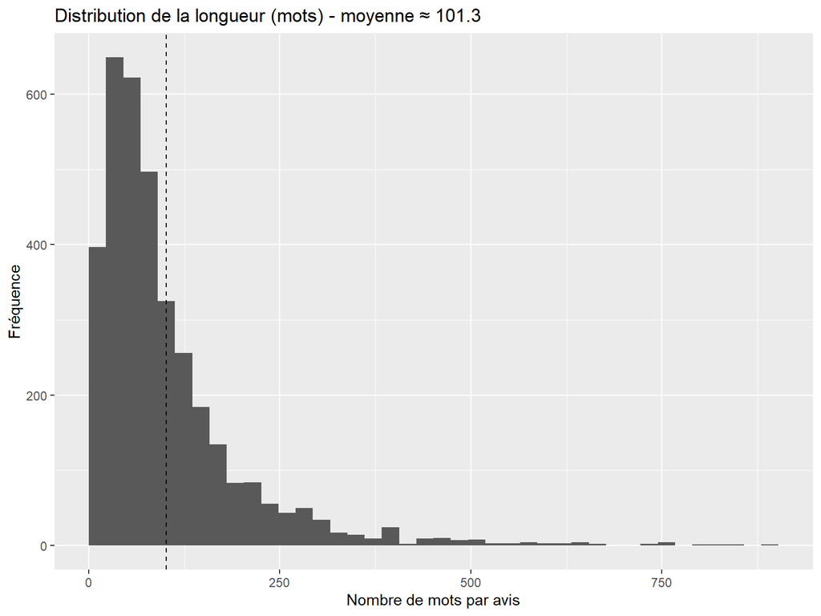

```r
avg <- mean(reviews$n_words, na.rm = TRUE)
ggplot(reviews, aes(n_words)) +
  geom_histogram(bins = 40, boundary = 0) +
  geom_vline(xintercept = avg, linetype = 2) +
  labs(x = "Nombre de mots par avis", y = "Fréquence",
       title = paste0("Distribution de la longueur (mots) - moyenne ≈ ", round(avg,1)))
```

## Ex. 6 - Tokenisation (format tidy)

> Une ligne = un mot. Conserver hashtags/mentions/émojis, retirer vides.

```r
tokens_tbl <- reviews |>
  select(review_id, txt) |>
  tidytext::unnest_tokens(token, txt, token = "words", to_lower = FALSE) |>
  filter(token != "")

head(tokens_tbl, 10)
```

```
# A tibble: 10 × 2
   review_id                token
   <chr>                    <chr>
 1 68c2dc48ef348c350e4ecf54 valérie
 2 68c2dc48ef348c350e4ecf54 de
 3 68c2dc48ef348c350e4ecf54 l
 4 68c2dc48ef348c350e4ecf54 acceuil
 5 68c2dc48ef348c350e4ecf54 de
 6 68c2dc48ef348c350e4ecf54 carrefour
 7 68c2dc48ef348c350e4ecf54 labege
 8 68c2dc48ef348c350e4ecf54 toulouse
 9 68c2dc48ef348c350e4ecf54 je
10 68c2dc48ef348c350e4ecf54 comprenais
```

## Ex. 7 - Stopwords FR & filtres utiles

> Enlevez **stopwords** FR, supprimez tokens numériques, gardez mots de ≥2 lettres (hors `#`/`@`).

```r
sw_fr <- stopwords::stopwords("fr", source = "stopwords-iso")

tokens_clean <- tokens_tbl |>
  filter(!(token %in% sw_fr)) |>
  filter(!stringr::str_detect(token, "^\\d+$")) |>
  filter(stringr::str_detect(token, "^#|^@|^[\\p{L}’'\\-]{2,}$"))

head(tokens_clean, 10)
```

```
# A tibble: 10 × 2
   review_id                token
   <chr>                    <chr>
 1 68c2dc48ef348c350e4ecf54 valérie
 2 68c2dc48ef348c350e4ecf54 acceuil
 3 68c2dc48ef348c350e4ecf54 carrefour
 4 68c2dc48ef348c350e4ecf54 labege
 5 68c2dc48ef348c350e4ecf54 toulouse
 6 68c2dc48ef348c350e4ecf54 comprenais
 7 68c2dc48ef348c350e4ecf54 matin
 8 68c2dc48ef348c350e4ecf54 montré
 9 68c2dc48ef348c350e4ecf54 compagne
10 68c2dc48ef348c350e4ecf54 doigt
```

## Ex. 8 - Fréquences & Top 20

```r
freq <- tokens_clean |>
  count(token, sort = TRUE)

freq %>% slice(1:20)
```

```
# A tibble: 20 × 2
   token             n
   <chr>         <int>
 1 carrefour      4288
 2 j'ai           1923
 3 commande       1657
 4 service        1584
 5 c'est          1310
 6 magasin        1289
 7 faire          1274
 8 client         1222
 9 produits        844
10 livraison       808
11 site            785
12 clients         726
13 prix            701
14 jamais          656
15 demande         615
16 drive           603
17 produit         598
18 j’ai            592
19 caisse          589
20 remboursement   584
```

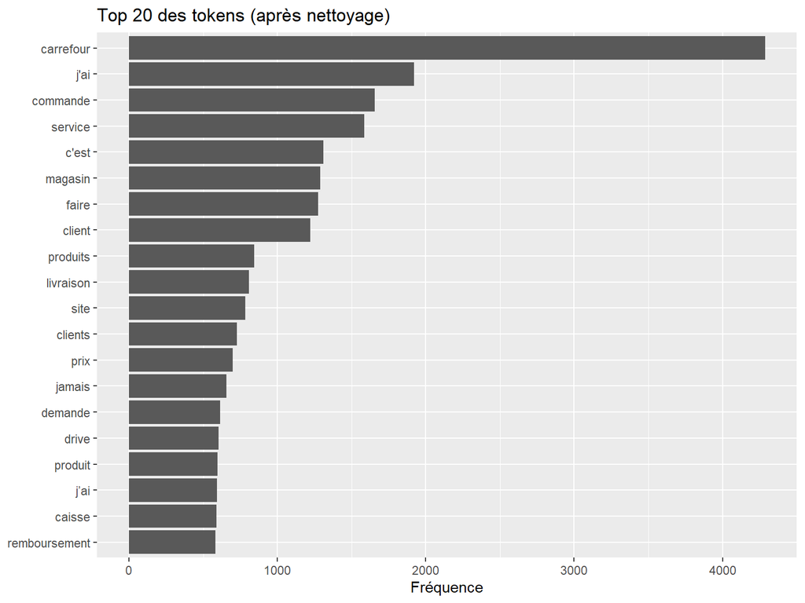

```r
ggplot(freq %>% slice(1:20), aes(x = reorder(token, n), y = n)) +
  geom_col() + coord_flip() +
  labs(x = NULL, y = "Fréquence", title = "Top 20 des tokens (après nettoyage)")
```

## Ex. 9 - Petite Zipf

> Rang + fréquence relative → nuage log–log.

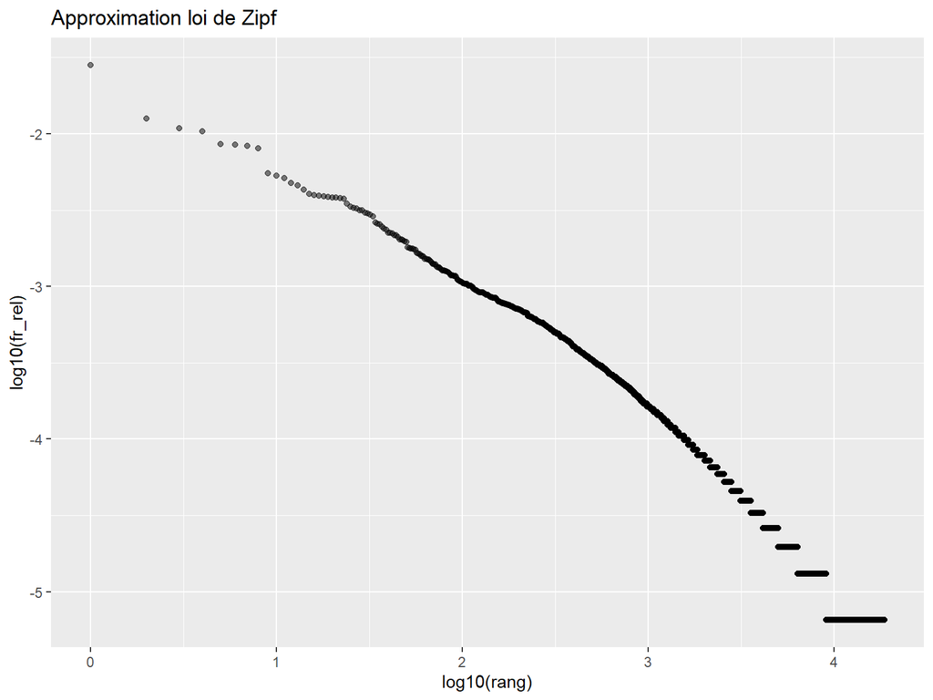

```r
zipf <- freq |>
  mutate(rank = row_number(),
         freq_rel = n / sum(n))

ggplot(zipf, aes(x = log10(rank), y = log10(freq_rel))) +
  geom_point(alpha = .5) +
  labs(x = "log10(rang)", y = "log10(fr_rel)", title = "Approximation loi de Zipf")
```

## Ex. 10 - Diversité lexicale (TTR) par avis

```r
ttr_by_doc <- tokens_clean |>
  group_by(review_id) |>
  summarise(types = n_distinct(token), tokens = n(), TTR = types / tokens, .groups = "drop")

summary(ttr_by_doc$TTR)
```

```
   Min. 1st Qu.  Median    Mean 3rd Qu.    Max.
 0.5455  0.8393  0.9091  0.8989  0.9756  1.0000
```

## Ex. 11 - Bigrams (2-grammes)

```r
bigrams <- reviews |>
  select(review_id, txt) |>
  tidytext::unnest_tokens(bigram, txt, token = "ngrams", n = 2)

bigrams_sep <- bigrams |>
  tidyr::separate(bigram, into = c("w1","w2"), sep = " ")

bigrams_clean <- bigrams_sep |>
  filter(!(w1 %in% sw_fr), !(w2 %in% sw_fr))

top_bi <- bigrams_clean |>
  tidyr::unite("bigram", w1, w2, sep = " ") |>
  count(bigram, sort = TRUE)

top_bi %>% slice(1:20)
```

```
# A tibble: 20 × 2
   bigram                   n
   <chr>                <int>
 1 service client         761
 2 carrefour market       232
 3 j'ai acheté            119
 4 j'ai commandé          115
 5 magasin carrefour      112
 6 carte pass              89
 7 service clients         86
 8 carrefour drive         79
 9 n'ai jamais             73
10 15 jours                66
11 geste commercial        66
12 site carrefour          66
13 1 mois                  64
14 carrefour online        64
15 publicité mensongère    63
16 client carrefour        60
17 2 jours                 59
18 site internet           59
19 3 jours                 58
20 3 semaines              56
```

## Ex. 12 - Keyness Index (tokens)

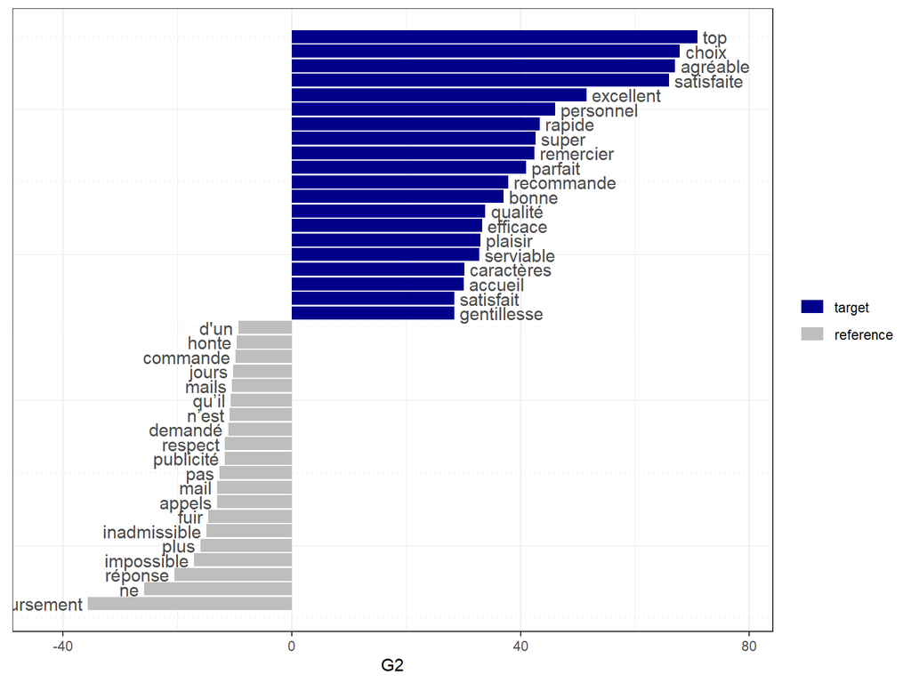

```r
# 0) Données : on écarte les avis = 3
reviews_key <- reviews %>%
  filter(!is.na(rating), rating != 3) %>%
  mutate(
    group = if_else(rating > 3, "high", "low"),
    text_col = txt
  )

# 1) Corpus & tokens (FR) - garder une partie de la négation
corp <- corpus(reviews_key, text_field = "text_col")
toks <- tokens(corp, remove_punct = TRUE, remove_numbers = TRUE, remove_symbols = TRUE) %>%
  tokens_tolower()

sw_keep <- setdiff(stopwords("fr", source = "stopwords-iso"),
                   c("ne","pas","jamais","plus"))
toks <- tokens_remove(toks, sw_keep)

# Retirer la marque
toks <- tokens_remove(toks, pattern = "carrefour*", valuetype = "glob")

# 2) DFM + trimming
dfm_mat <- dfm(toks) %>% dfm_trim(min_termfreq = 5)

# 3) Keyness (log-likelihood) : cible = avis positifs (>3)
K <- textstat_keyness(
  dfm_mat,
  target  = docvars(dfm_mat, "group") == "high",
  measure = "lr"  # -> colonne 'G2'
)

# 4) Côté >3 vs <3 : via fréquences relatives lissées (0.5)
tot_t <- sum(K$n_target); tot_r <- sum(K$n_reference)
K2 <- K %>%
  mutate(side = if_else(
    (n_target + 0.5) / (tot_t + 1) > (n_reference + 0.5) / (tot_r + 1),
    "pos",  # surreprésenté dans >3
    "neg"   # surreprésenté dans <3
  ))

# 5) Tops (classement par G2)
top_pos <- K2 %>% filter(side == "pos") %>% slice_max(G2, n = 30)
top_neg <- K2 %>% filter(side == "neg") %>% slice_max(G2, n = 30)

# 6) Visualisation
textplot_keyness(K, n = 20)
```

```r
# 7) Tables
top_pos
```

```
       feature       G2            p n_target n_reference side
1          top 70.94148 0.000000e+00       22          19  pos
2        choix 67.87716 2.220446e-16       34          81  pos
3     agréable 67.04027 2.220446e-16       22          22  pos
4   satisfaite 65.91877 4.440892e-16       19          13  pos
5    excellent 51.53296 7.041034e-13       10           0  pos
6    personnel 46.09467 1.126743e-11       40         176  pos
7       rapide 43.37258 4.524847e-11       18          29  pos
8        super 42.67416 6.466083e-11       23          57  pos
9    remercier 42.46516 7.195267e-11       12           7  pos
10     parfait 41.00919 1.515154e-10       13          11  pos
11  recommande 37.87152 7.556038e-10       22          60  pos
12       bonne 37.06758 1.141050e-09       29         116  pos
13     qualité 33.87690 5.871171e-09       29         126  pos
14    efficace 33.33903 7.741335e-09       11          10  pos
```

[output cut: 16 more lines]

```r
top_neg
```

```
            feature            G2         p n_target n_reference side
1       désagréable -0.0003247487 0.9856223        3          62  neg
2             crois -0.0003976235 0.9840908        1          27  neg
3        inexistant -0.0003976235 0.9840908        1          27  neg
4        renseigner -0.0003976235 0.9840908        1          27  neg
5          transmis -0.0003976235 0.9840908        1          27  neg
6                ok -0.0009632896 0.9752401        2          45  neg
7        ordinateur -0.0009632896 0.9752401        2          45  neg
8            puisse -0.0009632896 0.9752401        2          45  neg
9         connecter -0.0016433298 0.9676642        3          63  neg
10           colère -0.0034038103 0.9534761        1          28  neg
11        contraire -0.0034038103 0.9534761        1          28  neg
12              foi -0.0034038103 0.9534761        1          28  neg
13           oublié -0.0034038103 0.9534761        1          28  neg
14           papier -0.0034038103 0.9534761        1          28  neg
```

[output cut: 114 more lines]

## Ex. 13 - Aperçu POS (UDPipe) sur un échantillon

> Annotez ~300 avis (ou tout si moins) avec un modèle FR. Si besoin, **téléchargez** un modèle (bloc en bas).

```r
set.seed(123)
sample_ids <- sample(unique(reviews$review_id), size = min(300, nrow(reviews)))
sample_txt <- reviews |> filter(review_id %in% sample_ids) |> pull(txt)

# 1) Charger un modèle FR déjà présent en local si disponible
ud_model <- udpipe_load_model("french-gsd-ud-2.5-191206.udpipe")

# 2) Annotation
ann <- udpipe_annotate(ud_model, x = sample_txt, doc_id = as.character(sample_ids))
pos <- as_tibble(ann)

# Exemple de comptage des UPOS :
pos |> count(upos, sort = TRUE)
```

```
# A tibble: 18 × 2
   upos      n
   <chr> <int>
 1 NOUN   6873
 2 ADP    4602
 3 DET    4342
 4 VERB   4236
 5 PRON   3419
 6 PUNCT  3003
 7 ADV    2727
 8 ADJ    1734
 9 AUX    1498
10 CCONJ   958
11 NUM     807
12 <NA>    726
13 SCONJ   655
14 PROPN   470
15 SYM     224
16 X        96
17 INTJ     79
18 PART      4
```

## Ex. 13b - Keyness sur lemmes (UD, sous-échantillon)

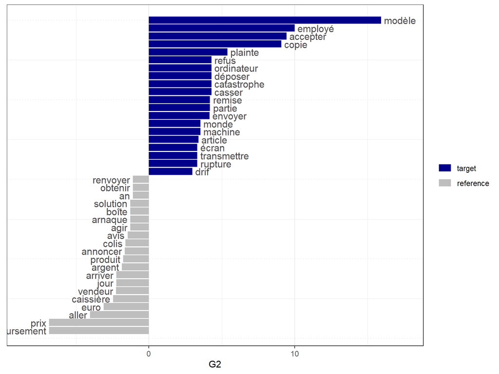

```r
# On se limite aux doc annotés dans `pos` + on rattache la polarité (>3 / <3)
sw_fr_keepneg <- setdiff(stopwords("fr", source = "stopwords-iso"),
                         c("pas","jamais","plus"))

grp_tbl <- reviews %>%
  transmute(doc_id = as.character(review_id),
            rating,
            group = if_else(!is.na(rating) & rating > 3, "high",
                            if_else(!is.na(rating) & rating < 3, "low", NA_character_))) %>%
  filter(!is.na(group))

lem_tbl <- pos %>%
  mutate(doc_id = as.character(doc_id),
         lemma  = tolower(lemma)) %>%
  filter(upos %in% c("NOUN","VERB","ADJ","ADV"),
         !is.na(lemma), nzchar(lemma)) %>%
  filter(!(lemma %in% sw_fr_keepneg)) %>%
  filter(!stringr::str_detect(lemma, "^carrefour")) %>%
  inner_join(grp_tbl, by = "doc_id")

# Agrégation doc → texte (concat lemmes)
lem_docs <- lem_tbl %>%
  group_by(doc_id) %>%
  summarise(group = dplyr::first(group),
            text  = paste(lemma, collapse = " "),
            .groups = "drop") %>%
  filter(nchar(text) > 0)

# Corpus → tokens → DFM
corp_l <- corpus(lem_docs, text_field = "text", docid_field = "doc_id")
toks_l <- tokens(corp_l, remove_punct = TRUE, remove_numbers = TRUE, remove_symbols = TRUE)
toks_l <- tokens_remove(toks_l, pattern = "carrefour*", valuetype = "glob")
toks_l <- toks_l[ntoken(toks_l) > 0]
dfm_l <- dfm(toks_l) %>% dfm_trim(min_termfreq = 5)

K_l <- textstat_keyness(
  dfm_l,
  target  = docvars(dfm_l, "group") == "high",
  measure = "lr"
)

# Côté pos/neg
tot_t <- sum(K_l$n_target); tot_r <- sum(K_l$n_reference)
K_l2 <- K_l %>%
  mutate(side = if_else(
    (n_target + 0.5)/(tot_t + 1) > (n_reference + 0.5)/(tot_r + 1),
    "pos","neg"
  ))

top_pos_lem <- K_l2 %>% filter(side == "pos") %>% slice_max(G2, n = 30)
top_neg_lem <- K_l2 %>% filter(side == "neg") %>% slice_max(G2, n = 30)

textplot_keyness(K_l, n = 20)
```

```r
top_pos_lem
```

```
       feature        G2            p n_target n_reference side
1       modèle 15.928381 6.578485e-05        5           0  pos
2      employé 10.004340 1.561717e-03        8          10  pos
3     accepter  9.448021 2.113770e-03        6           5  pos
4        copie  9.090161 2.569882e-03        4           1  pos
5      plainte  5.385842 2.030078e-02        6          10  pos
6       casser  4.289343 3.835198e-02        3           2  pos
7  catastrophe  4.289343 3.835198e-02        3           2  pos
8      déposer  4.289343 3.835198e-02        3           2  pos
9   ordinateur  4.289343 3.835198e-02        3           2  pos
10       refus  4.289343 3.835198e-02        3           2  pos
11      partie  4.196000 4.051945e-02        4           5  pos
12      remise  4.196000 4.051945e-02        4           5  pos
13     envoyer  4.167291 4.121165e-02       10          33  pos
14     machine  3.532044 6.019352e-02        4           6  pos
```

[output cut: 16 more lines]

```r
top_neg_lem
```

```
            feature            G2         p n_target n_reference side
1        expérience -0.0005398835 0.9814625        2          19  neg
2           changer -0.0034877265 0.9529067        1          12  neg
3           exemple -0.0034877265 0.9529067        1          12  neg
4             matin -0.0034877265 0.9529067        1          12  neg
5             offre -0.0034877265 0.9529067        1          12  neg
6           semaine -0.0104662348 0.9185149        4          35  neg
7           appeler -0.0104785529 0.9184671        2          20  neg
8             aimer -0.0212493942 0.8841016        0           5  neg
9            alcool -0.0212493942 0.8841016        0           5  neg
10       annulation -0.0212493942 0.8841016        0           5  neg
11            barre -0.0212493942 0.8841016        0           5  neg
12           cadeau -0.0212493942 0.8841016        0           5  neg
13         cagnotte -0.0212493942 0.8841016        0           5  neg
14        caractère -0.0212493942 0.8841016        0           5  neg
```

[output cut: 38 more lines]

## Ex. 14 - Couples adjectif → nom (*amod*)

```r
amod <- pos |>
   filter(dep_rel == "amod", upos == "ADJ") |>
   left_join(pos |> select(doc_id, sentence_id, token_id, head_lemma = lemma, head_upos = upos),
             by = c("doc_id","sentence_id","head_token_id" = "token_id")) |>
   filter(head_upos == "NOUN")

amod_pairs <- amod |>
   count(lemma, head_lemma, sort = TRUE)

amod_pairs %>% slice(1:20)
```

```
# A tibble: 20 × 3
   lemma      head_lemma     n
   <chr>      <chr>      <int>
 1 mensonger  publicité      7
 2 fidèle     client         6
 3 mauvais    expérience     6
 4 frais      produit        5
 5 gratuit    livraison      5
 6 même       chose          5
 7 onlin      carrefour      5
 8 tout       monde          5
 9 tout       produit        5
10 antibe     carrefour      4
11 autre      personne       4
12 central    caisse         4
13 cher       lecteur        4
14 même       jour           4
15 autre      enseigne       3
16 beau       arnaque        3
17 dernier    semaine        3
18 disponible article        3
19 drif       carrefour      3
20 drif       commande       3
```

## Ex. 15 - Wordcloud par rating (1 vs 5)

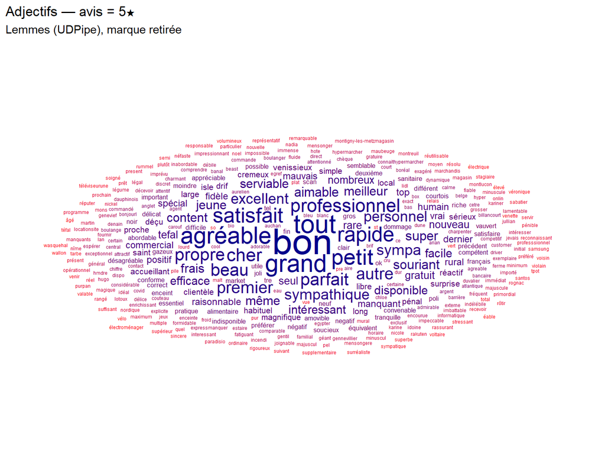

```r
# 1) Garder uniquement 1★ et 5★
# 1) Garder uniquement 1★ et 5★
reviews_adj <- reviews %>%
  dplyr::filter(!is.na(rating), rating %in% c(1, 5)) %>%
  dplyr::mutate(
    group  = dplyr::if_else(rating == 5, "star5", "star1"),
    doc_id = as.character(review_id),
    text   = txt
  )

# 2) Charger le modèle FR
ud_model <- udpipe::udpipe_load_model("french-gsd-ud-2.5-191206.udpipe")

# 3) Annotation UDPipe
ann <- udpipe::udpipe_annotate(ud_model, x = reviews_adj$text, doc_id = reviews_adj$doc_id)
pos <- tibble::as_tibble(ann)

# 4) Ne garder que les ADJECTIFS + nettoyage + retrait de la marque
adj <- pos %>%
  dplyr::filter(upos == "ADJ") %>%
  dplyr::transmute(doc_id = as.character(doc_id),
                   lemma  = tolower(lemma)) %>%
  dplyr::filter(!is.na(lemma), nzchar(lemma)) %>%
  dplyr::filter(stringr::str_detect(lemma, "^[\\p{L}’'-]{2,}$")) %>%
  dplyr::filter(!stringr::str_detect(lemma, "^carrefour"))

# 5) Rattacher le groupe et compter par groupe
adj_grp <- adj %>%
  dplyr::inner_join(reviews_adj %>% dplyr::select(doc_id, group), by = "doc_id") %>%
  dplyr::count(group, lemma, name = "frequency", sort = TRUE) %>%
  dplyr::group_by(group) %>%
  dplyr::mutate(rank = dplyr::row_number()) %>%
  dplyr::ungroup()

# 6) Limiter pour lisibilité
N <- 200
adj_top <- adj_grp %>%
  dplyr::group_by(group) %>%
  dplyr::slice_max(frequency, n = N) %>%
  dplyr::ungroup()

# 7) Séparer 5★ / 1★
adj_5 <- adj_top %>% dplyr::filter(group == "star5")
adj_1 <- adj_top %>% dplyr::filter(group == "star1")

# 8) Deux wordclouds (pas de facet)
set.seed(42)
p_5 <- ggplot2::ggplot(adj_5, ggplot2::aes(label = lemma)) +
  ggwordcloud::geom_text_wordcloud(ggplot2::aes(size = frequency, color = rank)) +
  ggplot2::scale_size_area(max_size = 12) +                 # <— ICI
  ggplot2::scale_color_gradient(low = "darkblue", high = "red") +
  ggplot2::theme_minimal() +
  ggplot2::labs(title = "Adjectifs — avis = 5★",
                subtitle = "Lemmes (UDPipe), marque retirée",
                size = "Fréquence", color = "Rang")

set.seed(43)
p_1 <- ggplot2::ggplot(adj_1, ggplot2::aes(label = lemma)) +
  ggwordcloud::geom_text_wordcloud(ggplot2::aes(size = frequency, color = rank)) +
  ggplot2::scale_size_area(max_size = 12) +                 # <— ET LÀ
  ggplot2::scale_color_gradient(low = "darkblue", high = "red") +
  ggplot2::theme_minimal() +
  ggplot2::labs(title = "Adjectifs — avis = 1★",
                subtitle = "Lemmes (UDPipe), marque retirée",
                size = "Fréquence", color = "Rang")

# 9) Afficher
p_5
```

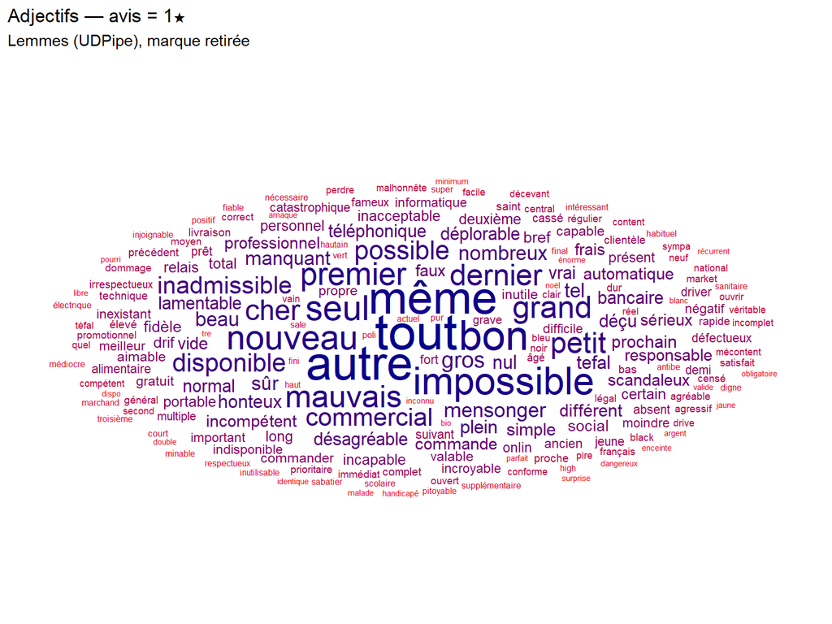

```r
p_1
```

## Ex. 15 - Mini-interprétation (3–5 puces)

> - 2 thèmes saillants (tokens/bigrams)
> - 2 adjectifs les plus associés (Ex. 14) + intérêt marketing
> - 1 piste d’amélioration du parcours (livraison, SAV, promo, etc.)

## (Option) Petit détour par `quanteda` (DFM rapide)

```r
corp <- corpus(reviews, text_field = "txt")
toks <- tokens(corp, remove_punct = TRUE, remove_numbers = TRUE) |>
  tokens_tolower() |>
  tokens_remove(sw_fr)

dfm_mat <- dfm(toks)
head(quanteda.textstats::textstat_frequency(dfm_mat), 20)
```

```
     feature frequency rank docfreq group
1  carrefour      4277    1    2290   all
2       j'ai      1923    2     978   all
3   commande      1650    3     839   all
4    service      1577    4     933   all
5      c'est      1308    5     859   all
6    magasin      1288    6     812   all
7      faire      1274    7     901   all
8     client      1221    8     815   all
9   produits       844    9     551   all
10         €       819   10     435   all
11 livraison       807   11     485   all
12      site       785   12     548   all
13   clients       724   13     543   all
14      prix       698   14     473   all
15    jamais       656   15     527   all
16   demande       615   16     441   all
17     drive       603   17     352   all
18   produit       598   18     394   all
19      j’ai       592   19     304   all
20    caisse       589   20     362   all
```

```r
# Collocations (bigrams) :
quanteda.textstats::textstat_collocations(toks, size = 2) |>
   arrange(desc(lambda)) |>
   head(20)
```

```
                        collocation count count_nested length   lambda        z
2635                   black friday    37            0      2 16.95985 8.451792
4106                   gousse d’ail     4            0      2 14.83980 7.221994
4671                  access denied     2            0      2 14.25203 6.794381
4672                 alain afflelou     2            0      2 14.25203 6.794381
4673                    beyond meat     2            0      2 14.25203 6.794381
4674                 bilal loubnazi     2            0      2 14.25203 6.794381
4675                     bouts d'os     2            0      2 14.25203 6.794381
4676            calories consommées     2            0      2 14.25203 6.794381
4677                examen oculaire     2            0      2 14.25203 6.794381
4678             falsifier bulletin     2            0      2 14.25203 6.794381
4679         franceil heuresbonjour     2            0      2 14.25203 6.794381
4680                françoise dorin     2            0      2 14.25203 6.794381
4681                 gente féminine     2            0      2 14.25203 6.794381
4682              gratin dauphinois     2            0      2 14.25203 6.794381
4683 intervenue.cependant adressant     2            0      2 14.25203 6.794381
4684                    karim amina     2            0      2 14.25203 6.794381
4685                   leroy merlin     2            0      2 14.25203 6.794381
4686             liberte tourniquet     2            0      2 14.25203 6.794381
4687                 loubnazi karim     2            0      2 14.25203 6.794381
4688                metz technopole     2            0      2 14.25203 6.794381
```

## 📥 Télécharger un modèle FR pour UDPipe (au cas où)

Le fichier du modèle FR est disponible à la racine du cours 4 et se nomme `french-gsd-ud-2.5-191206.udpipe`. Si besoin de le charger localement ou de le télécharger puis de le charger :

```r
# OPTION A - Téléchargement automatique
# m <- udpipe_download_model(language = "french-gsd")
# ud_model <- udpipe_load_model(m$file_model)

# OPTION B - Chargement depuis un fichier local
# ud_model <- udpipe_load_model("french-gsd-ud-2.5-191206.udpipe")
```